# Predicting payment method from transaction characteristic

Kai Foerster, Krishnamoorty Manohara, Laura Menicacci, Andrew Wells

2022-05-12

## Abstract

The introduction of mobile money services is revolutionising the financial lives of low-income households in Kenya by giving them access to formal financial services. While M-Pesa has a potential to change the financial lives of poor Kenyan households, usage of mobile money in everyday financial transactions is less understood.

This study runs explainable machine learning algorithms on the Kenya Financial Diaries, a high-frequency financial transaction dataset. The best algorithm, which is the Random Forest classifier, is able to predict the transaction method for a given transaction with a 98.52% accuracy and an MCC of 93.55%. The main predictors of mobile money transactions were transactions related to: remittances, telecom providers, monthly consumption and income measures as well as mental and physical health characteristics. These findings contribute to a greater understanding of the financial lives of low-income Kenyans.

## Background

**What is M-Pesa?**

Though app-based cash transfer systems such as PayPal and CashApp are becoming more common, M-Pesa (“M” for mobile and “Pesa” for the Kiswahili world for money) pre-dated these systems when it was introduced in Kenya in 2007 by cellphone providers Safaricom and Vodafone. While money transfer systems such as Western Union have operated for many years, fees were debilitatingly high for people making small payments. M-Pesa gives a cheap and convenient way to transfer money via SMS.

## Related Work

In ”Mobile Banking: The Impact of M-Pesa in Kenya,” (Mbiti 2011) detail the history of M-Pesa. They describe the pre-MPesa (before 2007) transfer economy as mainly operating through cash and informal transfers, such as trade and barter. The available cash transfer services,such as Western Union were prohibitively expensive. But M-Pesa has allowed for users to send smaller amounts more frequently, offering necessary sources of cash, especially in rural areas (Morawczynski 2009). Therefore, mobile money services have also been considered a powerful tool for poverty reduction. In particular, low transaction fees have enabled poor households to tap into a larger network of relatives and friends when requesting financial assistance to overcome sudden income shocks (Jack and Suri 2014). Jack and Suri(2014) estimate that households receiving mobile money remittances in Kenya were able to offset a negative income shock, while households without access to mobile money suffered a consumption drop of 7% on average. The Financial Diaries tracked these developments in real time. It tracked all transactions made by 298 low-income households in Kenya between July 2012 and December 2013, making this dataset an ideal source of data to predict mobile money usage and analyse the conditions under which transaction take place.

## Methods and tools

We figured that, by employing some of the usual of machine learning, such as logistic regression, ridge regression, decision trees, support vector machines, and random rorests, we could find a classification algorithm for best predicting modes of transactions, in terms of whether mobile money was used or not. Furthermore, the machine learning algorithms named above are interpretable! That means, we could use them to understand which feature are important to predict the usage of mobile money. Keeping in mind that our classes were strongly imbalanced, we used four evaluation metrics to check on the prediction performance on the differently distributed categories: Accuracy (the classical one), F1 score, the Matthew’s correlation coefficient and the ROC-AUC score. With these four measures, we were able to understand which model was performing better in predicting minority classes as the mobile money one, despite the high numbers given by the accuracy score, that could happen to be misleading. For the baseline, we used a Random Rate Classifier, which is just a fancy name for just guessing the class. Since the classes were unbalanced, we weighted the guessed classes according to their relative frequencies in the training data.

## Experiments

The Decision Tree was constructed using sklearn. It had a maximum depth of 50 nodes between the root and leaves. We chose this model over more performance-oriented models since it is not a black box, and the decision-making process that it “learns” can be easily visualized. Since one of our primary goals with this project was to identify which characteristics of the transactions and subjects were more influential in deciding their method of transaction, this was important. By taking a look at the generated tree, we could see clearly which were the best questions to ask to gain the most information on the target.

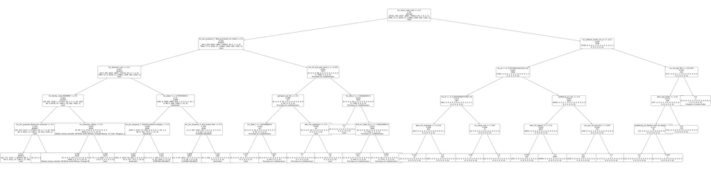

Decision Tree

This image is just a sample, in reality the generated tree was far deeper and had many more nodes. When training the Decision Tree, a tradeoff had to be made in terms of tree depth; deeper trees had greater space and time complexity, while also being more accurate. However, trees that were too deep would be less accurate, since they would be overfit on the training data. Hence, we calculated metrics for trees of different depths, evaluated on a previously unseen validation set.

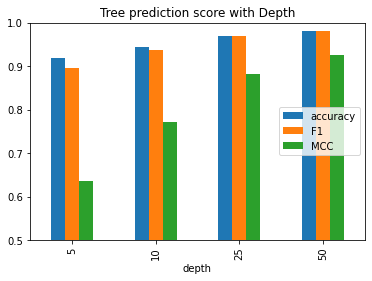

Decision Tree performance

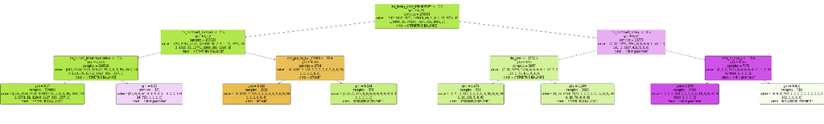

Tree visualization from Random Forest classifier

Our project was able to detect the most important features that predict a mobile money transaction. Apart from administrative features such as “month since the first transaction was recorded” which are not informative, the re-occurring important features across models were related to remittances, telecom providers, monthly consumption and income as well as mental and physical health characteristics.

## Analysis

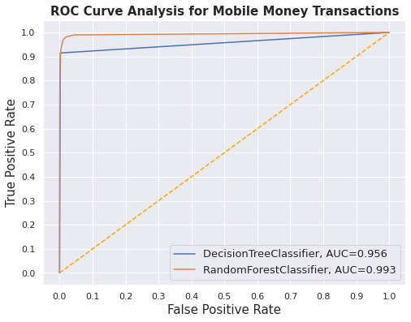

ROC-AUC Curve for the best two models with a selected sample

The figure above represents the final output of this project. In this plot, we recoded the target variable (payment method) using a one-vs-all strategy. We wanted to understand how the model could behave in predicting only one of these classes, mobile money, as such class has always represented the goal of our research question. We plotted the ROCAUC curve for our two best models, namely the Random Forest with 25 trees and the Decision Tree with a depth of 50. We chose the best performing decision tree, and the number of trees in the Random Forest that acted like a cutoff in our GridSearch training. We observed indeed that after 25 trees, the model wasn’t improving significantly as before.

According to the ROC-AUC score, the performance is outperforming for both of the models. These two algorithms indeed were able to gain a high score even with such a strict metric. The ROC-AUC Curve plotted here reflects such performances also on the prediction of a class that is present in only the 2% of the data.

Two things are mostly important to notice when looking at such a graph. Firstly, the AUC (Area Under the Curve): the larger the area, the better the model will be in its true positive prediction rate. We notice that the Random Forest with 25 is slightly better than the Decision Tree, with a smoother curve. This latter one has indeed a strong change of direction at a specific point, meaning that after that threshold the model started to predict only false positives. Another important thing to observe in the ROC-AUC, is the steepness of the curves. We can say that both models reach the top left of the curve in a strikingly similar way.

## Acknowledgments

We would like to thank FSD Kenya for providing the data online through its website and Harvard dataverse. We are also grateful to Eric Kolibacz for his advice during labs. We are also grateful for the countless advice we found online on multiple coding problems we ran into.

## References

Jack, William, and Tavneet Suri. 2014. “Risk Sharing and Transaction Costs: Evidence from Kenya’s Mobile Money Revolution.” *American Economic Review* 104 (1): 183–223.

Mbiti, David, Isaac; Weil. 2011. “Mobile Banking: The Impact of m-Pesa in Kenya.” *National Bureau of Economic Research*.

Morawczynski, Olan. 2009. *Exploring the Usage and Impact of "Transformational" Mobile Financial Services: The Case of m-PESA in Kenya*. *Journal of Eastern African Studies*.

Navis, K. 2014. “And the World Leader in Mobile Money Adoption Is. (Not Where You Think).”